# 1. Una empresa que fabrica electrodomésticos desea mejorar sus ganancias en el próximo año. Actualmente, la empresa invierte en medios publicitarios como televisión, radio y periódicos. La empresa registra el dinero invertido en cada medio publicitario (en miles de dólares) y la cantidad de unidades de producto vendidas (en miles de unidades). Usted es contratado como consultor y tiene la misión de construir un modelo predictivo que le ayude a la empresa a determinar la forma más eficaz de invertir el dinero en publicidad de tal manera que se logre un incrementó en las ventas. Para esta tarea la empresa le suministra los datos disponibles en [https://raw.githubusercontent.com/jpospinalo/MachineLearning/main/Linear%20Regression/advertising2.csv]

```python
import numpy as np
import matplotlib.pyplot as plt
import pandas as pd
import seaborn as sns
# Entrenamiento
from sklearn.model_selection import train_test_split
# Transformacion
from sklearn.impute import SimpleImputer
from sklearn.preprocessing import MinMaxScaler
from sklearn.preprocessing import StandardScaler
from sklearn.pipeline import Pipeline
from sklearn.compose import ColumnTransformer
# Modelos
from sklearn.pipeline import make_pipeline
from sklearn.linear_model import LinearRegression
from sklearn.preprocessing import PolynomialFeatures
from sklearn.metrics import r2_score
import itertools
from sklearn.neighbors import KNeighborsRegressor
# Statsmodels
import statsmodels.api as sm


raw = "https://raw.githubusercontent.com/jpospinalo/MachineLearning/main/Linear%20Regression/advertising2.csv"
```

## Preparación de los datos

```python
df = pd.read_csv(raw)
df.info()
```

```
<class 'pandas.core.frame.DataFrame'>
RangeIndex: 208 entries, 0 to 207
Data columns (total 4 columns):
 #   Column     Non-Null Count  Dtype
---  ------     --------------  -----
 0   TV         200 non-null    float64
 1   Radio      200 non-null    float64
 2   Newspaper  200 non-null    float64
 3   Sales      208 non-null    object
dtypes: float64(3), object(1)
memory usage: 6.6+ KB
```

```python
df['Sales'] = df['Sales'].str.replace(',', '.')
df['Sales'] = pd.to_numeric(df['Sales'], errors='coerce')
df.info()
```

```
<class 'pandas.core.frame.DataFrame'>
RangeIndex: 208 entries, 0 to 207
Data columns (total 4 columns):
 #   Column     Non-Null Count  Dtype
---  ------     --------------  -----
 0   TV         200 non-null    float64
 1   Radio      200 non-null    float64
 2   Newspaper  200 non-null    float64
 3   Sales      208 non-null    float64
dtypes: float64(4)
memory usage: 6.6 KB
```

```python
df.isna().sum()
```

|  | 0 |
| --- | --- |
| TV | 8 |
| Radio | 8 |
| Newspaper | 8 |
| Sales | 0 |

**dtype:** int64

```python
# NO tocar test
train, test = train_test_split(df, test_size=0.2, random_state=42)
```

```python
print("80% de los datos (train)\n",train.isna().sum(),"\n")
print("20% de los datos (test)\n",test.isna().sum())
```

```
80% de los datos (train)
 TV           8
Radio        8
Newspaper    8
Sales        0
dtype: int64

20% de los datos (test)
 TV           0
Radio        0
Newspaper    0
Sales        0
dtype: int64
```

## Analisis Descriptivo

```python
df.describe()
```

|  | TV | Radio | Newspaper | Sales |
| --- | --- | --- | --- | --- |
| count | 200.000000 | 200.000000 | 200.000000 | 208.000000 |
| mean | 147.042500 | 23.264000 | 30.554000 | 15.130500 |
| std | 85.854236 | 14.846809 | 21.778621 | 5.180782 |
| min | 0.700000 | 0.000000 | 0.300000 | 1.600000 |
| 25% | 74.375000 | 9.975000 | 12.750000 | 11.225000 |
| 50% | 149.750000 | 22.900000 | 25.750000 | 15.500000 |
| 75% | 218.825000 | 36.525000 | 45.100000 | 18.900000 |
| max | 296.400000 | 49.600000 | 114.000000 | 27.000000 |

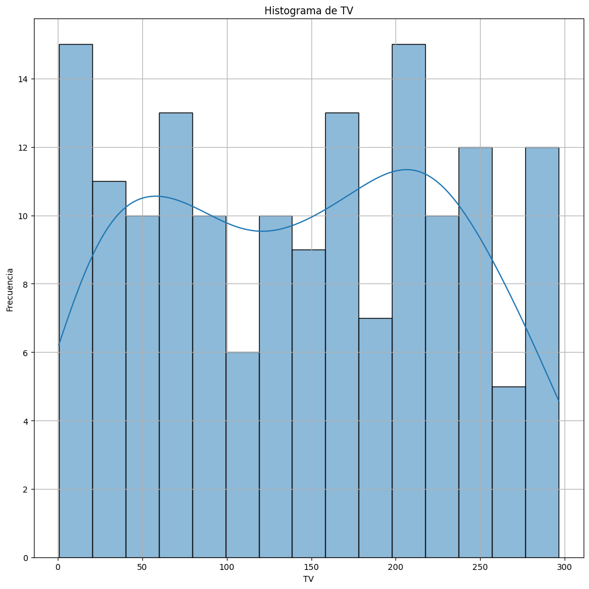

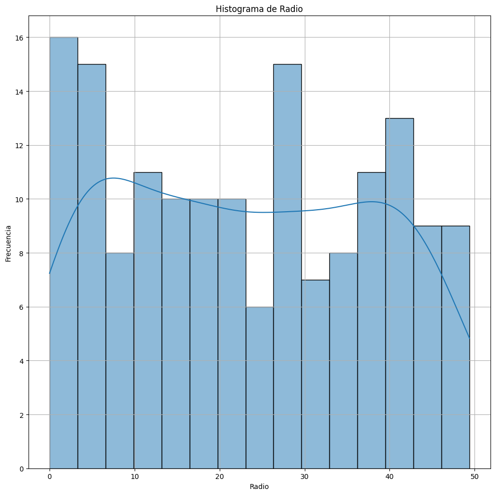

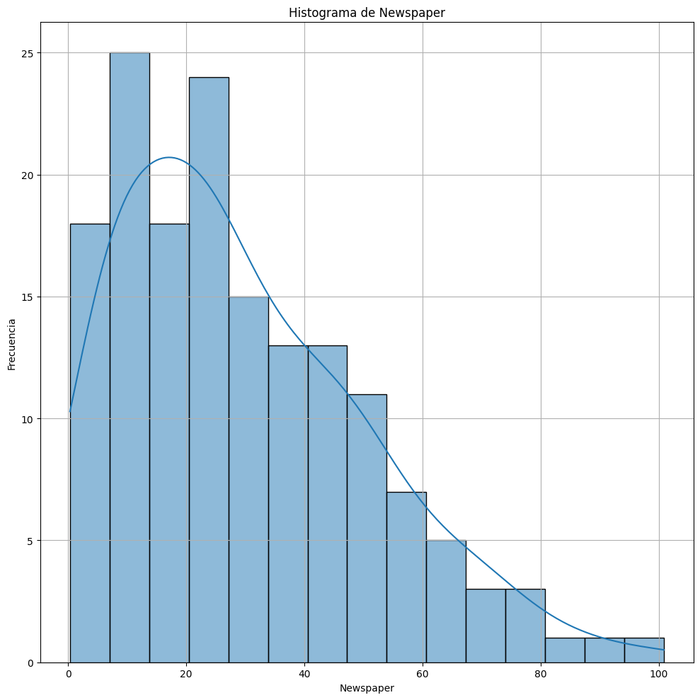

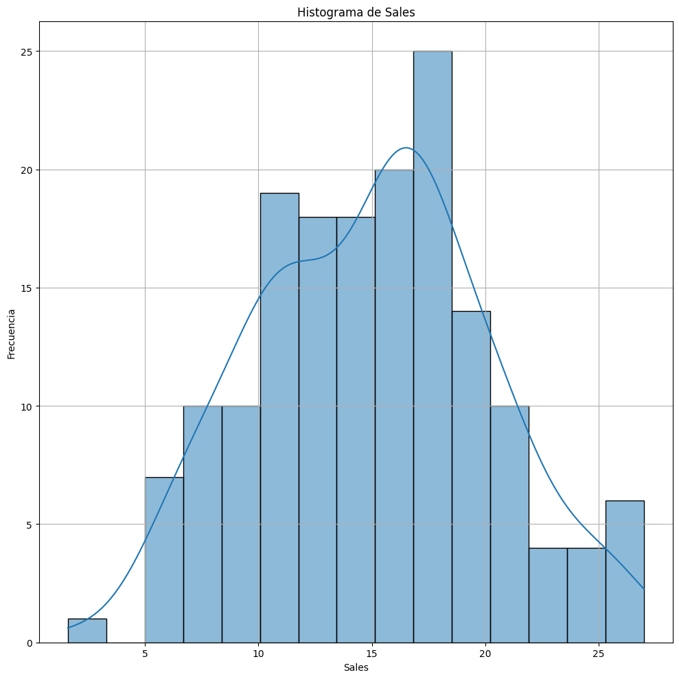

```python
plt.figure(figsize=(10,10))
sns.histplot(train['TV'], kde=True, bins=15)
plt.title('Histograma de TV')
plt.xlabel('TV')
plt.ylabel('Frecuencia')
plt.tight_layout()
plt.grid(True)
plt.show()

plt.figure(figsize=(10,10))
sns.histplot(train['Radio'], kde=True, bins=15)
plt.title('Histograma de Radio')
plt.xlabel('Radio')
plt.ylabel('Frecuencia')
plt.tight_layout()
plt.grid(True)
plt.show()

plt.figure(figsize=(10,10))
sns.histplot(train['Newspaper'], kde=True, bins=15)
plt.title('Histograma de Newspaper')
plt.xlabel('Newspaper')
plt.ylabel('Frecuencia')
plt.tight_layout()
plt.grid(True)
plt.show()

plt.figure(figsize=(10,10))
sns.histplot(train['Sales'], kde=True, bins=15)
plt.title('Histograma de Sales')
plt.xlabel('Sales')
plt.ylabel('Frecuencia')
plt.tight_layout()
plt.grid(True)
plt.show()
```

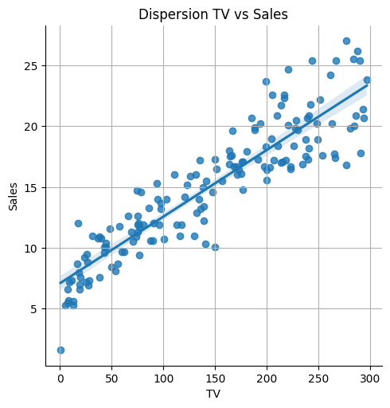

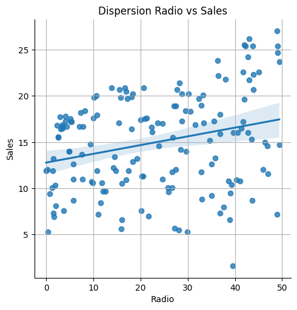

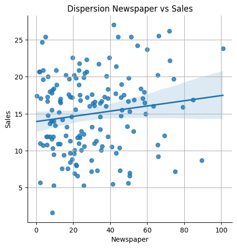

```python
plt.figure(figsize=(10, 6))
sns.lmplot(x='TV', y='Sales', data=train)
plt.title('Dispersion TV vs Sales')
plt.grid(True)
plt.show()

plt.figure(figsize=(10, 6))
sns.lmplot(x='Radio', y='Sales', data=train)
plt.title('Dispersion Radio vs Sales')
plt.grid(True)
plt.show()

plt.figure(figsize=(10, 6))
sns.lmplot(x='Newspaper', y='Sales', data=train)
plt.title('Dispersion Newspaper vs Sales')
plt.grid(True)
plt.show()
```

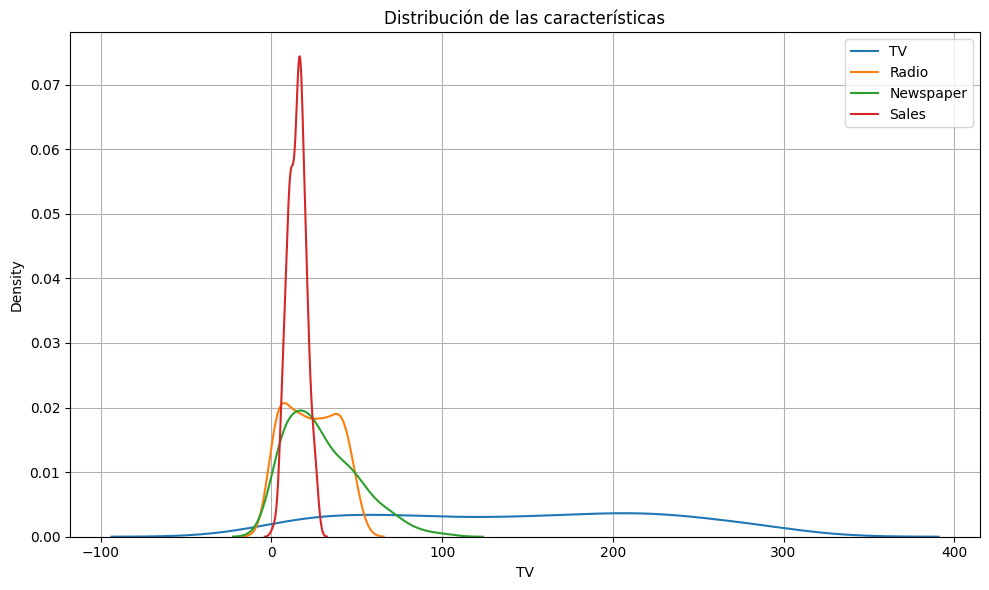

```python
plt.figure(figsize=(10, 6))
for col in ['TV', 'Radio', 'Newspaper', 'Sales']:
    sns.kdeplot(train[col], label=col)
plt.legend()
plt.title("Distribución de las características")
plt.tight_layout()
plt.grid(True)
plt.show()
```

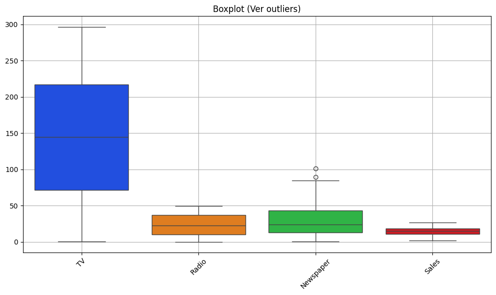

```python
plt.figure(figsize=(10, 6))
sns.boxplot(data=train, palette='bright')
plt.title('Boxplot (Ver outliers)')
plt.xticks(rotation=45)
plt.tight_layout()
plt.grid(True)
plt.show()
```

```python
antesIQR = train.describe()
```

```python
Q1 = train[['TV', 'Radio', 'Newspaper', 'Sales']].quantile(0.25)
Q3 = train[['TV', 'Radio', 'Newspaper', 'Sales']].quantile(0.75)
IQR = Q3 - Q1

trained = train[~((train < (Q1 - 1.5 * IQR)) | (train > (Q3 + 1.5 * IQR))).any(axis=1)]

despuesIQR = trained.describe()
```

```python
print("Antes de IQR:\n", antesIQR)
print("\nDespués de IQR:\n", despuesIQR)
```

```
Antes de IQR:
                TV       Radio   Newspaper       Sales
count  158.000000  158.000000  158.000000  166.000000
mean   143.963924   23.209494   29.702532   14.984602
std     86.664688   14.976456   20.996217    5.109538
min      0.700000    0.000000    0.300000    1.600000
25%     71.300000    9.925000   12.825000   11.000000
50%    144.300000   22.400000   24.250000   15.165250
75%    216.700000   36.725000   43.175000   18.150000
max    296.400000   49.400000  100.900000   27.000000

Después de IQR:
                TV       Radio   Newspaper       Sales
count  156.000000  156.000000  156.000000  164.000000
mean   143.801282   22.994231   28.863462   14.969171
std     85.753002   14.944142   19.751580    5.070346
min      0.700000    0.000000    0.300000    1.600000
25%     72.700000    9.825000   12.700000   11.000000
50%    144.300000   22.000000   23.950000   15.165250
75%    216.500000   36.575000   43.025000   18.050000
max    293.600000   49.400000   84.800000   27.000000
```